# Network analysis using DNA metabarcoding data discloses important roles and links in the seabird community of the Eastern Tropical Atlantic

### 3.4.3 Comparisons of Network level metrics with Null model

Null model:

```r
nulls <- nullmodel(host_season.network$caboverde, N= 1000, method = "vaznull")
```

- **weighted NODF:**

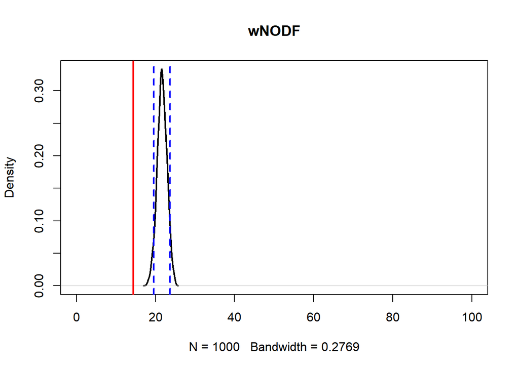

```r
obs_wNODF <- network_indeces[1]

nulls_wNODF <- sapply(nulls, function(x) networklevel(x, index = "weighted NODF")[1])
plot(density(nulls_wNODF), xlim=c(0, 100), lwd=2, main="wNODF")
abline(v=c(quantile(nulls_wNODF, 0.05), quantile(nulls_wNODF, 0.95), obs_wNODF), col=c("blue","blue", "red"), lty=c(2,2,1), lwd=c(2,2,2))
```

- **H2:**

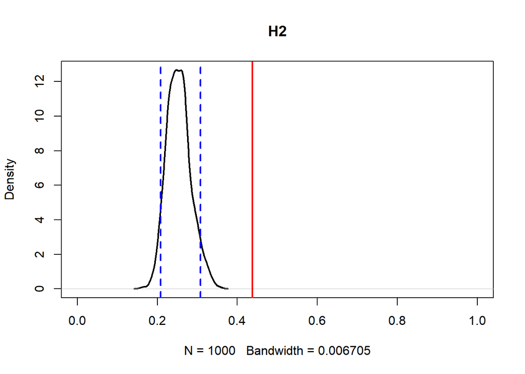

```r
obs_H2 <- network_indeces[2]

nulls_H2 <- sapply(nulls, function(x) networklevel(x, index = "H2")[1])
plot(density(nulls_H2), xlim=c(0, 1), lwd=2, main="H2")
abline(v=c(quantile(nulls_H2, 0.05), quantile(nulls_H2, 0.95), obs_H2), col=c("blue","blue", "red"), lty=c(2,2,1), lwd=c(2,2,2))
```

- **Modularity:**

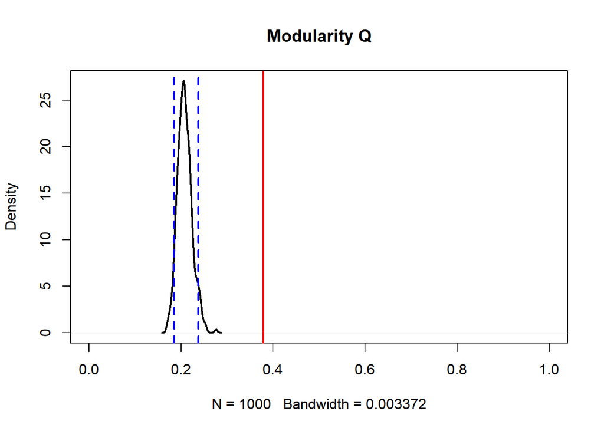

```r
nulls_Q <- sapply(nulls, function(x) metaComputeModules(x)@likelihood)

plot(density(nulls_Q), xlim=c(0, 1), lwd=2, main="Modularity Q")
abline(v=c(quantile(nulls_Q, 0.05), quantile(nulls_Q, 0.95), obs_Q), col=c("blue","blue", "red"), lty=c(2,2,1), lwd=c(2,2,2))
```

### 3.4.4 Module based metrics (Cz-values)

```r
host_season.HL.cz <- czvalues(host_season.net.mod)
host_season.HL.cz <- as.data.frame(host_season.HL.cz)

host_season.LL.cz <- czvalues(host_season.net.mod, level = "lower")
host_season.LL.cz <- as.data.frame(host_season.LL.cz)

host_season.HL.cz
```

|  | c | z |
| --- | --- | --- |
| BB_Summer | 0.4359862 | NA |
| CE_Summer | 0.6528926 | NA |
| PA_Summer | 0.3466667 | 0.7071068 |
| PA_Winter | 0.6426593 | NA |
| PB_Winter | 0.4930748 | 0.7071068 |
| SL_Summer | 0.6640625 | -0.7071068 |
| SL_Winter | 0.6280992 | -0.7071068 |

```r
host_season.LL.cz
```

|  | c | z |
| --- | --- | --- |
| Acanthuridae | 0.0000000 | -0.6094494 |
| Acanthurus sp. | 0.0000000 | 0.0000000 |
| Apletodon sp. | 0.0000000 | 0.0000000 |
| Argyropelecus sladeni | 0.0000000 | 0.0000000 |
| Arothron sp. | 0.7500000 | -0.6094494 |
| Assimineidae | 0.0000000 | 0.0000000 |
| Asthenognathus atlanticus | 0.0000000 | -0.6094494 |
| Atherina sp. | 0.0000000 | 0.0000000 |
| Brotula sp. | 0.0000000 | 0.0000000 |
| Carangidae | 0.0000000 | -0.6094494 |
| Cavolinia uncinata | 0.0000000 | -0.6831301 |
| Cephalopholis sp. | 0.6250000 | 1.5236235 |
| Ceratoscopelus sp. | 0.0000000 | 0.0000000 |
| Chelon auratus | 0.0000000 | 0.0000000 |
| Chromis chromis | 0.7755102 | 0.0000000 |
| Conger conger | 0.0000000 | 0.0000000 |
| Coryphaena equiselis | 0.5000000 | 0.0000000 |
| Cyclothone pallida | 0.0000000 | 0.0000000 |
| Decapterus macarellus | 0.6250000 | 1.5236235 |
| Decapterus punctactus | 0.0000000 | -0.6094494 |
| Derichthys serpentinus | 0.0000000 | 0.0000000 |
| Diacria sp.1 | 0.0000000 | -0.6831301 |
| Diacria sp.2 | 0.0000000 | -0.6831301 |
| Diplodus sargus | 0.0000000 | 0.0000000 |
| Diplodus vulgaris | 0.0000000 | 0.0000000 |
| Engraulis encrasicolus | 0.6666667 | 0.0000000 |
| Engraulis sp. | 0.0000000 | 0.0000000 |
| Exocoetidae | 0.0000000 | -0.6094494 |
| Exocoetidae 2 | 0.6250000 | 1.3662601 |
| Exocoetus obtusirostris | 0.5000000 | 0.0000000 |
| Exocoetus volitans | 0.7755102 | 1.3662601 |
| Gempylus serpens | 0.0000000 | -0.6831301 |
| Gymnothorax vicinus | 0.6666667 | -0.6094494 |
| Hirundichthys sp. | 0.0000000 | -0.6831301 |
| Histioteuthis meleagroteuthis | 0.0000000 | 0.0000000 |
| Hyaloteuthis pelagica | 0.0000000 | 0.0000000 |
| Ichthyococcus sp. | 0.0000000 | 0.0000000 |
| Katsuwonus pelamis | 0.6666667 | 0.0000000 |
| Lagocephalus lagocephalus | 0.6250000 | 1.3662601 |
| Lampanyctus intricarius | 0.0000000 | -0.6831301 |
| Lampanyctus sp.1 | 0.0000000 | 0.0000000 |
| Lampanyctus sp.2 | 0.0000000 | 0.0000000 |
| Lampanyctus sp.3 | 0.0000000 | 1.3662601 |
| Lampanyctus sp.4 | 0.0000000 | -0.6831301 |
| Lepidophanes guentheri | 0.0000000 | 0.0000000 |
| Macroramphosus sp. | 0.0000000 | -0.6094494 |
| Microstomatidae | 0.0000000 | 0.0000000 |
| Mola mola | 0.5000000 | 0.0000000 |
| Moridae | 0.0000000 | 0.0000000 |
| Myliobatis aquila | 0.0000000 | 0.0000000 |
| Naucrates ductor | 0.0000000 | 0.0000000 |
| Nomeus gronovii | 0.6250000 | 1.5236235 |
| Oplopomus oplopomus | 0.0000000 | -0.6094494 |
| Oxyporhamphus similis | 0.7777778 | 1.3662601 |
| Phosichthyidae | 0.6666667 | 0.0000000 |
| Phrosina semilunata | 0.0000000 | -0.6831301 |
| Pseudupeneus prayensis | 0.0000000 | 0.0000000 |
| Sardina pilchardus | 0.6666667 | -0.6831301 |
| Scomber sp. | 0.0000000 | 0.0000000 |
| Scomberesox saurus | 0.6250000 | 1.5236235 |
| Scomberesox sp. | 0.0000000 | 0.0000000 |
| Selene setapinnis | 0.5000000 | -0.6094494 |
| Seriola lalandi | 0.6666667 | 0.0000000 |
| Solea senegalensis | 0.0000000 | 0.0000000 |
| Sparidae 1 | 0.0000000 | 0.0000000 |
| Sparidae 2 | 0.0000000 | 0.0000000 |
| Squalus sp. | 0.0000000 | 0.0000000 |
| Sternoptyx pseudopallida | 0.0000000 | 0.0000000 |
| Sthenoteuthis pteropus | 0.0000000 | 0.0000000 |
| Stomiidae | 0.0000000 | 0.0000000 |
| Symphodus bailloni | 0.0000000 | 0.0000000 |
| Symphodus melops | 0.0000000 | 0.0000000 |
| Thunnus sp.1 | 0.5000000 | 0.0000000 |
| Thunnus sp.2 | 0.7777778 | 0.0000000 |
| Trichiuridae | 0.0000000 | -0.6831301 |

### 3.4.5 Comparisons of Module based metrics with Null model

Null model cz-values:

```r
nulls_cvalues_HL <- sapply(nulls, function(x) czvalues(metaComputeModules(x))$c)
quantile(nulls_cvalues_HL, 0.95)
```

```
##       95%
## 0.6844444
```

```r
nulls_zvalues_HL <- sapply(nulls, function(x) czvalues(metaComputeModules(x))$z)
nulls_zvalues_HL[is.na(nulls_zvalues_HL)] <- 0
quantile(nulls_zvalues_HL, 0.95)
```

```
##       95%
## 0.7071068
```

```r
nulls_cvalues_LL <- sapply(nulls, function(x) czvalues(metaComputeModules(x), level = "lower")$c)
quantile(nulls_cvalues_LL, 0.95)
```

```
##  95%
## 0.72
```

```r
nulls_zvalues_LL <- sapply(nulls, function(x) czvalues(metaComputeModules(x), level = "lower")$z)
nulls_zvalues_LL[is.na(nulls_zvalues_LL)] <- 0
quantile(nulls_zvalues_LL, 0.95)
```

```
##      95%
## 1.884843
```

Plots

- **Higher level**

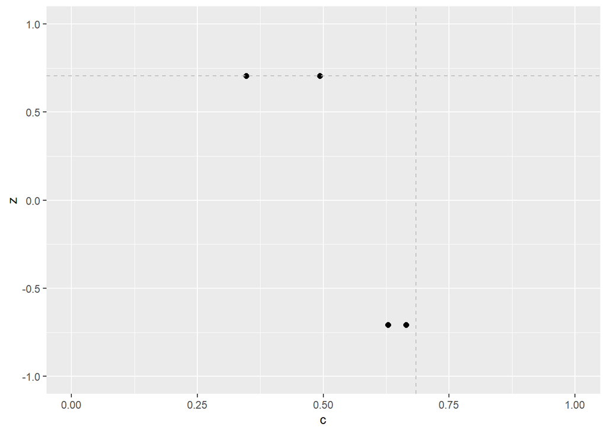

```r
HL_czplot <- ggplot(host_season.HL.cz, aes(x=c, y=z)) +
  xlim(0, 1) +
  ylim(-1, 1) +
  geom_point(size = 2) +
  geom_vline(xintercept = quantile(nulls_cvalues_HL, 0.95), linetype="dashed", color = "grey") +
  geom_hline(yintercept = quantile(nulls_zvalues_HL, 0.95), linetype="dashed", color = "grey") +
  geom_text_repel(data=subset(host_season.HL.cz, c > quantile(nulls_cvalues_HL, 0.95) | z > quantile(nulls_zvalues_HL, 0.95)), aes(label = row.names(subset(host_season.HL.cz, c > quantile(nulls_cvalues_HL, 0.95) | z > quantile(nulls_zvalues_HL, 0.95)))))

HL_czplot
```

- **Lower level**

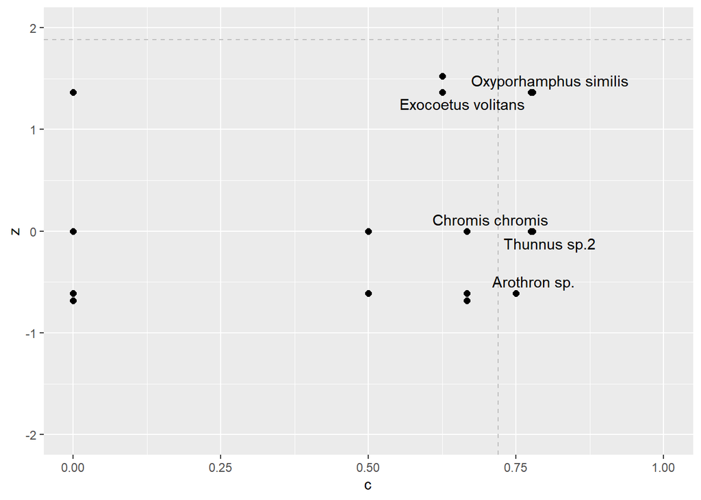

```r
LL_czplot <- ggplot(host_season.LL.cz, aes(x=c, y=z)) +
  xlim(0, 1) +
  ylim(-2, 2) +
  geom_point(size = 2) +
  geom_vline(xintercept = quantile(nulls_cvalues_LL, 0.95), linetype="dashed", color = "grey") +
  geom_hline(yintercept = quantile(nulls_zvalues_LL, 0.95), linetype="dashed", color = "grey") +
  geom_text_repel(data=subset(host_season.LL.cz, c > quantile(nulls_cvalues_LL, 0.95) | z > quantile(nulls_zvalues_LL, 0.95)), aes(label = row.names(subset(host_season.LL.cz, c > quantile(nulls_cvalues_LL, 0.95) | z > quantile(nulls_zvalues_LL, 0.95)))))

LL_czplot
```

## 3.5 Network analysis using FI

```r
host_season.net.matrix <- host_season.matrix.motu.long.good[,c(1,3,5)] %>% filter(present > 0) %>% dplyr::rename(higher = host_season, lower = Species, freq = present)
host_season.net.matrix$webID = "caboverde"
host_season.net.matrix <- host_season.net.matrix[, c(1, 2, 4, 3)]

seq.high <- as.data.frame(host_season.net.matrix$higher)%>% dplyr::rename(seq.high = "host_season.net.matrix$higher") %>% distinct(seq.high)
seq.low <- as.data.frame(host_season.net.matrix$lower)%>% dplyr::rename(seq.low = "host_season.net.matrix$lower") %>% distinct(seq.low)

host_season.network <- frame2webs(data.frame(host_season.net.matrix),type.out="list")
```

### 3.5.1 Species level metrics

```r
specieslevel(host_season.network$caboverde, index=c("normalised degree", "d"))
```

```
## $`higher level`
##           normalised.degree         d
## BB_Summer         0.4533333 0.5522861
## CE_Summer         0.2933333 0.3954666
## PA_Summer         0.2000000 0.3427068
## PA_Winter         0.2533333 0.2142667
## PB_Winter         0.2533333 0.3859814
## SL_Summer         0.2133333 0.2133649
## SL_Winter         0.1466667 0.2139601
##
## $`lower level`
##                               normalised.degree          d
## Acanthuridae                          0.1428571 0.13498253
## Acanthurus sp.                        0.1428571 0.06769065
## Apletodon sp.                         0.1428571 0.06769065
## Argyropelecus sladeni                 0.1428571 0.06769065
## Arothron sp.                          0.5714286 0.09277382
## Assimineidae                          0.1428571 0.06769065
## Asthenognathus atlanticus             0.1428571 0.13498253
## Atherina sp.                          0.1428571 0.29924699
## Brotula sp.                           0.1428571 0.06769065
## Carangidae                            0.1428571 0.13498253
## Cavolinia uncinata                    0.1428571 0.21046212
## Cephalopholis sp.                     0.5714286 0.13249707
## Ceratoscopelus sp.                    0.1428571 0.06769065
## Chelon auratus                        0.1428571 0.20689541
## Chromis chromis                       1.0000000 0.03328780
## Conger conger                         0.1428571 0.07263012
## Coryphaena equiselis                  0.2857143 0.21081731
## Cyclothone pallida                    0.1428571 0.07263012
## Decapterus macarellus                 0.5714286 0.08149942
## Decapterus punctactus                 0.1428571 0.09898151
## Derichthys serpentinus                0.1428571 0.07263012
## Diacria sp.1                          0.1428571 0.21046212
## Diacria sp.2                          0.1428571 0.21046212
## Diplodus sargus                       0.1428571 0.06769065
## Diplodus vulgaris                     0.1428571 0.06769065
## Engraulis encrasicolus                0.4285714 0.24821758
## Engraulis sp.                         0.1428571 0.06769065
## Exocoetidae                           0.1428571 0.13498253
```

[output cut: 32 more lines]

```
## Scomberesox sp.                       0.1428571 0.06769065
## Selene setapinnis                     0.2857143 0.07241180
## Seriola lalandi                       0.4285714 0.20582776
## Solea senegalensis                    0.1428571 0.06769065
## Sparidae 1                            0.1428571 0.20689541
## Sparidae 2                            0.1428571 0.06769065
## Squalus sp.                           0.1428571 0.20689541
## Sternoptyx pseudopallida              0.1428571 0.06769065
## Sthenoteuthis pteropus                0.1428571 0.06769065
## Stomiidae                             0.1428571 0.07263012
## Symphodus bailloni                    0.1428571 0.06769065
## Symphodus melops                      0.1428571 0.06769065
## Thunnus sp.1                          0.2857143 0.30785588
## Thunnus sp.2                          0.8571429 0.13559005
## Trichiuridae                          0.1428571 0.21046212
```

### 3.5.2 Network level metrics

- **Network indices**

```r
network_indeces <- networklevel(host_season.network$caboverde, index=c("weighted NODF", "H2"))
network_indeces
```

```
## weighted NODF            H2
##    14.3119314     0.2623814
```

- **Modularity**

```r
host_season.net.mod <- metaComputeModules(host_season.network$caboverde, N=500)
obs_Q <- host_season.net.mod@likelihood
obs_Q
```

```
## [1] 0.3787232
```

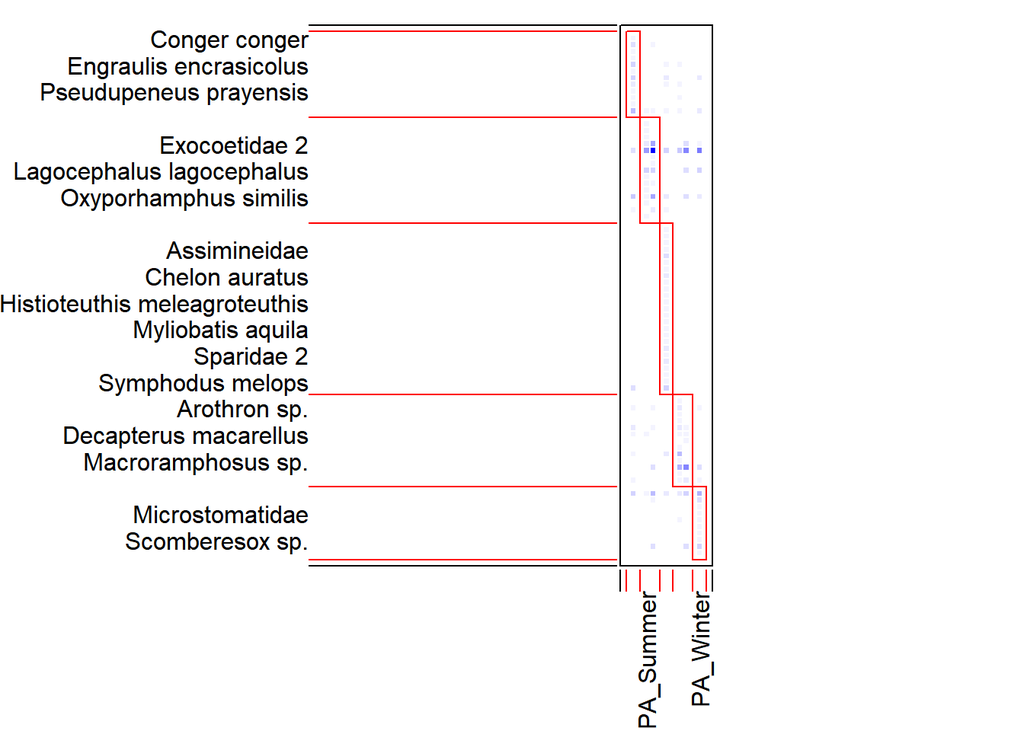

```r
plotModuleWeb(host_season.net.mod)
```

### 3.5.3 Comparisons of Network level metrics with Null model

Null model:

```r
nulls <- nullmodel(host_season.network$caboverde, N= 1000, method = "vaznull")
```

- **weighted NODF:**

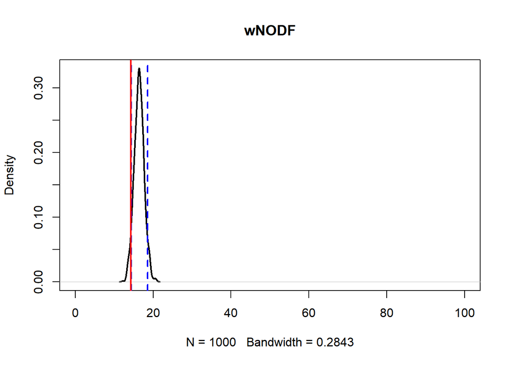

```r
obs_wNODF <- network_indeces[1]

nulls_wNODF <- sapply(nulls, function(x) networklevel(x, index = "weighted NODF")[1])
plot(density(nulls_wNODF), xlim=c(0, 100), lwd=2, main="wNODF")
abline(v=c(quantile(nulls_wNODF, 0.05), quantile(nulls_wNODF, 0.95), obs_wNODF), col=c("blue","blue", "red"), lty=c(2,2,1), lwd=c(2,2,2))
```

- **H2:**

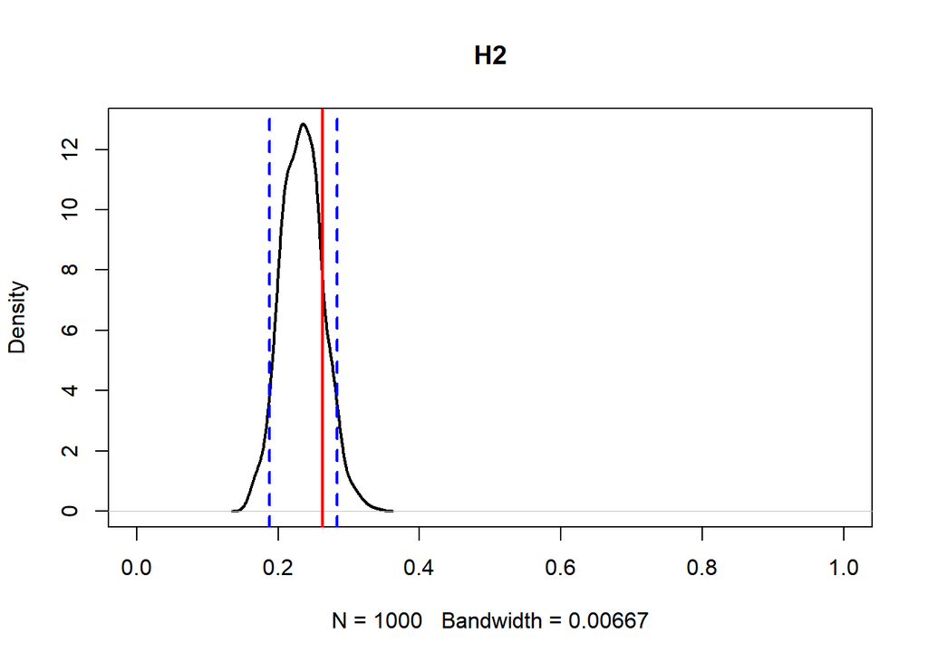

```r
obs_H2 <- network_indeces[2]

nulls_H2 <- sapply(nulls, function(x) networklevel(x, index = "H2")[1])
plot(density(nulls_H2), xlim=c(0, 1), lwd=2, main="H2")
abline(v=c(quantile(nulls_H2, 0.05), quantile(nulls_H2, 0.95), obs_H2), col=c("blue","blue", "red"), lty=c(2,2,1), lwd=c(2,2,2))
```

- **Modularity:**

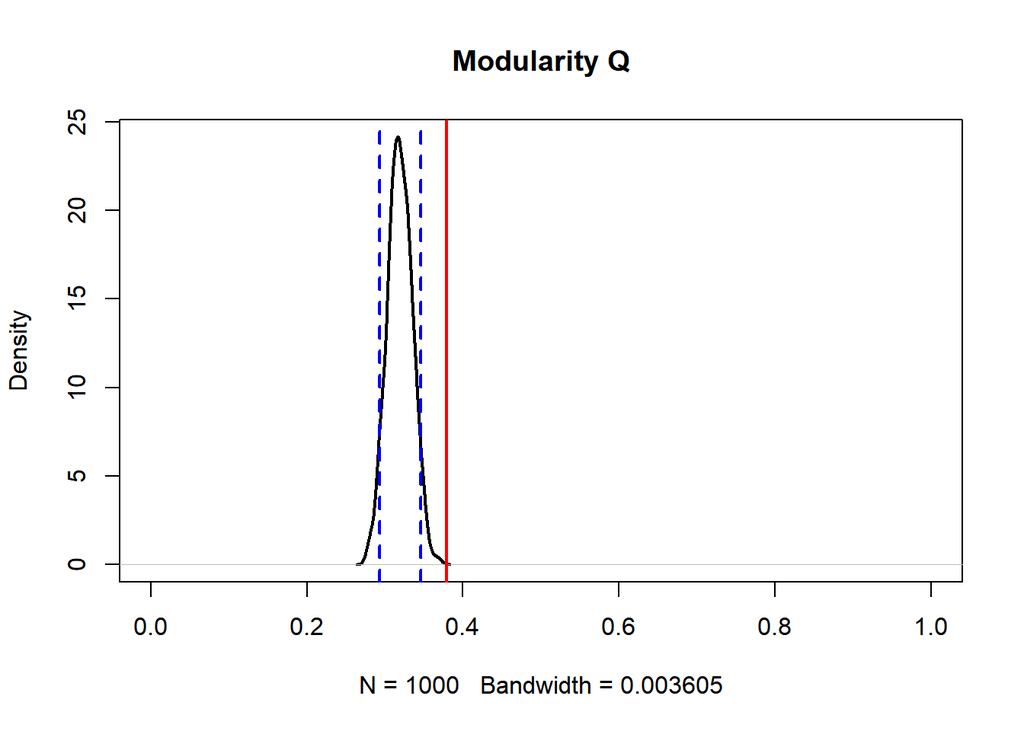

```r
nulls_Q <- sapply(nulls, function(x) metaComputeModules(x)@likelihood)

plot(density(nulls_Q), xlim=c(0, 1), lwd=2, main="Modularity Q")
abline(v=c(quantile(nulls_Q, 0.05), quantile(nulls_Q, 0.95), obs_Q), col=c("blue","blue", "red"), lty=c(2,2,1), lwd=c(2,2,2))
```

### 3.5.4 Module based metrics (Cz-values)

```r
host_season.HL.cz <- czvalues(host_season.net.mod)
host_season.HL.cz <- as.data.frame(host_season.HL.cz)

host_season.LL.cz <- czvalues(host_season.net.mod, level = "lower")
host_season.LL.cz <- as.data.frame(host_season.LL.cz)

host_season.HL.cz
```

|  | c | z |
| --- | --- | --- |
| BB_Summer | 0.4359862 | NA |
| CE_Summer | 0.6280992 | NA |
| PA_Summer | 0.3466667 | 0.7071068 |
| PA_Winter | 0.6426593 | NA |
| PB_Winter | 0.5429363 | 0.7071068 |
| SL_Summer | 0.6640625 | -0.7071068 |
| SL_Winter | 0.6280992 | -0.7071068 |

```r
host_season.LL.cz
```

|  | c | z |
| --- | --- | --- |
| Acanthuridae | 0.0000000 | -0.6405126 |
| Acanthurus sp. | 0.0000000 | 0.0000000 |
| Apletodon sp. | 0.0000000 | 0.0000000 |
| Argyropelecus sladeni | 0.0000000 | 0.0000000 |
| Arothron sp. | 0.7500000 | -0.6405126 |
| Assimineidae | 0.0000000 | 0.0000000 |
| Asthenognathus atlanticus | 0.0000000 | -0.6405126 |
| Atherina sp. | 0.0000000 | 0.0000000 |
| Brotula sp. | 0.0000000 | 0.0000000 |
| Carangidae | 0.0000000 | -0.6405126 |
| Cavolinia uncinata | 0.0000000 | -0.6831301 |
| Cephalopholis sp. | 0.6250000 | 1.4411534 |
| Ceratoscopelus sp. | 0.0000000 | 0.0000000 |
| Chelon auratus | 0.0000000 | 0.0000000 |
| Chromis chromis | 0.7755102 | 0.0000000 |
| Conger conger | 0.0000000 | 0.0000000 |
| Coryphaena equiselis | 0.5000000 | 0.0000000 |
| Cyclothone pallida | 0.0000000 | 0.0000000 |
| Decapterus macarellus | 0.6250000 | 1.4411534 |
| Decapterus punctactus | 0.0000000 | -0.6405126 |
| Derichthys serpentinus | 0.0000000 | 0.0000000 |
| Diacria sp.1 | 0.0000000 | -0.6831301 |
| Diacria sp.2 | 0.0000000 | -0.6831301 |
| Diplodus sargus | 0.0000000 | 0.0000000 |
| Diplodus vulgaris | 0.0000000 | 0.0000000 |
| Engraulis encrasicolus | 0.6666667 | 0.0000000 |
| Engraulis sp. | 0.0000000 | 0.0000000 |
| Exocoetidae | 0.0000000 | -0.6405126 |
| Exocoetidae 2 | 0.6250000 | 1.3662601 |
| Exocoetus obtusirostris | 0.5000000 | 0.0000000 |
| Exocoetus volitans | 0.7755102 | 1.3662601 |
| Gempylus serpens | 0.0000000 | -0.6831301 |
| Gymnothorax vicinus | 0.6666667 | -0.6405126 |
| Hirundichthys sp. | 0.0000000 | -0.6831301 |
| Histioteuthis meleagroteuthis | 0.0000000 | 0.0000000 |
| Hyaloteuthis pelagica | 0.0000000 | 0.0000000 |
| Ichthyococcus sp. | 0.0000000 | 0.0000000 |
| Katsuwonus pelamis | 0.6666667 | 0.0000000 |
| Lagocephalus lagocephalus | 0.6250000 | 1.3662601 |
| Lampanyctus intricarius | 0.0000000 | -0.6831301 |
| Lampanyctus sp.1 | 0.0000000 | 0.0000000 |
| Lampanyctus sp.2 | 0.0000000 | 0.0000000 |
| Lampanyctus sp.3 | 0.0000000 | 1.3662601 |
| Lampanyctus sp.4 | 0.0000000 | -0.6831301 |
| Lepidophanes guentheri | 0.0000000 | 0.0000000 |
| Macroramphosus sp. | 0.0000000 | -0.6405126 |
| Microstomatidae | 0.0000000 | 0.0000000 |
| Mola mola | 0.5000000 | 0.0000000 |
| Moridae | 0.0000000 | 0.0000000 |
| Myliobatis aquila | 0.0000000 | 0.0000000 |
| Naucrates ductor | 0.0000000 | 0.0000000 |
| Nomeus gronovii | 0.6250000 | 1.4411534 |
| Oplopomus oplopomus | 0.0000000 | -0.6405126 |
| Oxyporhamphus similis | 0.7777778 | 1.3662601 |
| Phosichthyidae | 0.6666667 | 0.0000000 |
| Phrosina semilunata | 0.0000000 | -0.6831301 |
| Pseudupeneus prayensis | 0.0000000 | 0.0000000 |
| Sardina pilchardus | 0.6666667 | -0.6831301 |
| Scomber sp. | 0.0000000 | 0.0000000 |
| Scomberesox saurus | 0.6250000 | 1.4411534 |
| Scomberesox sp. | 0.0000000 | 0.0000000 |
| Selene setapinnis | 0.5000000 | 0.0000000 |
| Seriola lalandi | 0.6666667 | 0.0000000 |
| Solea senegalensis | 0.0000000 | 0.0000000 |
| Sparidae 1 | 0.0000000 | 0.0000000 |
| Sparidae 2 | 0.0000000 | 0.0000000 |
| Squalus sp. | 0.0000000 | 0.0000000 |
| Sternoptyx pseudopallida | 0.0000000 | 0.0000000 |
| Sthenoteuthis pteropus | 0.0000000 | 0.0000000 |
| Stomiidae | 0.0000000 | 0.0000000 |
| Symphodus bailloni | 0.0000000 | 0.0000000 |
| Symphodus melops | 0.0000000 | 0.0000000 |
| Thunnus sp.1 | 0.5000000 | 0.0000000 |
| Thunnus sp.2 | 0.7777778 | 0.0000000 |
| Trichiuridae | 0.0000000 | -0.6831301 |

### 3.5.5 Comparisons of Module based metrics with Null model

Null model cz-values:

```r
nulls_cvalues_HL <- sapply(nulls, function(x) czvalues(metaComputeModules(x))$c)
quantile(nulls_cvalues_HL, 0.95)
```

```
##  95%
## 0.73
```

```r
nulls_zvalues_HL <- sapply(nulls, function(x) czvalues(metaComputeModules(x))$z)
nulls_zvalues_HL[is.na(nulls_zvalues_HL)] <- 0
quantile(nulls_zvalues_HL, 0.95)
```

```
##       95%
## 0.7071068
```

```r
nulls_cvalues_LL <- sapply(nulls, function(x) czvalues(metaComputeModules(x), level = "lower")$c)
quantile(nulls_cvalues_LL, 0.95)
```

```
##  95%
## 0.75
```

```r
nulls_zvalues_LL <- sapply(nulls, function(x) czvalues(metaComputeModules(x), level = "lower")$z)
nulls_zvalues_LL[is.na(nulls_zvalues_LL)] <- 0
quantile(nulls_zvalues_LL, 0.95)
```

```
##      95%
## 1.502938
```

Plots

- **Higher level**

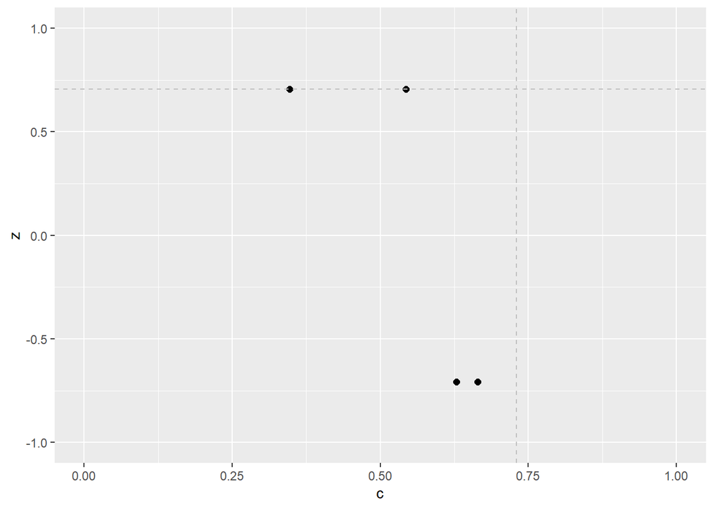

```r
HL_czplot <- ggplot(host_season.HL.cz, aes(x=c, y=z)) +
  xlim(0, 1) +
  ylim(-1, 1) +
  geom_point(size = 2) +
  geom_vline(xintercept = quantile(nulls_cvalues_HL, 0.95), linetype="dashed", color = "grey") +
  geom_hline(yintercept = quantile(nulls_zvalues_HL, 0.95), linetype="dashed", color = "grey") +
  geom_text_repel(data=subset(host_season.HL.cz, c > quantile(nulls_cvalues_HL, 0.95) | z > quantile(nulls_zvalues_HL, 0.95)), aes(label = row.names(subset(host_season.HL.cz, c > quantile(nulls_cvalues_HL, 0.95) | z > quantile(nulls_zvalues_HL, 0.95)))))

HL_czplot
```

- **Lower level**

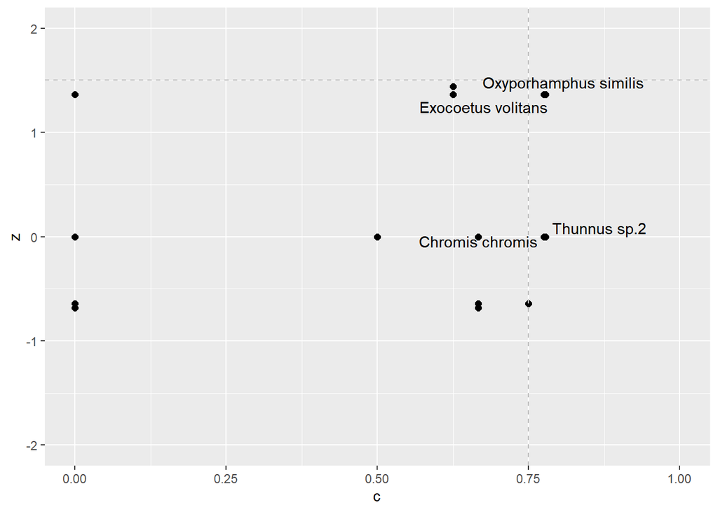

```r
LL_czplot <- ggplot(host_season.LL.cz, aes(x=c, y=z)) +
  xlim(0, 1) +
  ylim(-2, 2) +
  geom_point(size = 2) +
  geom_vline(xintercept = quantile(nulls_cvalues_LL, 0.95), linetype="dashed", color = "grey") +
  geom_hline(yintercept = quantile(nulls_zvalues_LL, 0.95), linetype="dashed", color = "grey") +
  geom_text_repel(data=subset(host_season.LL.cz, c > quantile(nulls_cvalues_LL, 0.95) | z > quantile(nulls_zvalues_LL, 0.95)), aes(label = row.names(subset(host_season.LL.cz, c > quantile(nulls_cvalues_LL, 0.95) | z > quantile(nulls_zvalues_LL, 0.95)))))

LL_czplot
```

## 3.6 Pianka niche overlap between populations

The Pianka overlap index was calculated, and the significance of each overlap was calculated over a simulated matrix using ecosimR. HJ was excluded from this analysis due to its low sample size.

```r
overlap.host_season.motu.data <- host_season.matrix.motu.wide.good[-1]
overlap.host_season.motu.data2 <- as.data.frame(t(overlap.host_season.motu.data))

pianka.host_season.motu <- niche.overlap(overlap.host_season.motu.data2, method = "pianka")
pianka.host_season.motu
```

```
##           BB_Summer CE_Summer PA_Summer PA_Winter PB_Winter SL_Summer
## CE_Summer 0.5396468
## PA_Summer 0.3999477 0.3238672
## PA_Winter 0.4586359 0.4721565 0.7916959
## PB_Winter 0.3480617 0.3445409 0.3967254 0.5339881
## SL_Summer 0.4691821 0.4329451 0.8824269 0.8699926 0.4843980
## SL_Winter 0.3466596 0.3184224 0.6777781 0.8072883 0.7193129 0.8057088
```

Niche overlap comparisons between each pair of populations:

### 3.6.1 BB vs CE

```r
summary(ecosim_BB_CE)
```

```
## Time Stamp:  Tue Jan 24 05:33:12 2023
## Reproducible:  FALSE
## Number of Replications:  1000
## Elapsed Time:  0.16 secs
## Metric:  pianka
## Algorithm:  ra3
## Observed Index:  0.53965
## Mean Of Simulated Index:  0.25957
## Variance Of Simulated Index:  0.0068391
## Lower 95% (1-tail):  0.13284
## Upper 95% (1-tail):  0.39851
## Lower 95% (2-tail):  0.11623
## Upper 95% (2-tail):  0.44002
## Lower-tail P =  1
## Upper-tail P =  0.002
## Observed metric > 998 simulated metrics
## Observed metric < 0 simulated metrics
## Observed metric = 2 simulated metrics
## Standardized Effect Size (SES):  3.3867
```

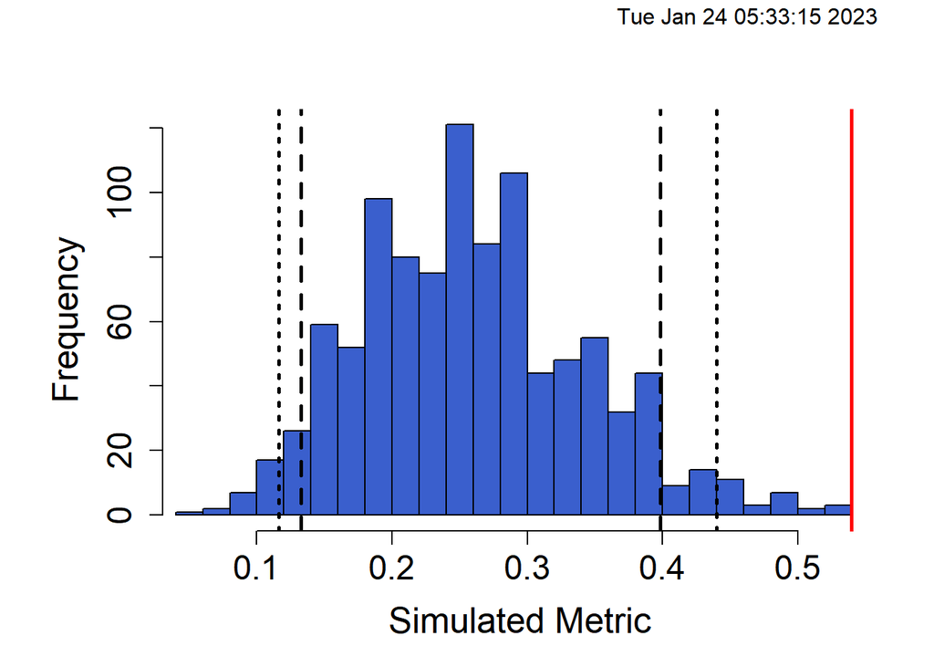

```r
plot(ecosim_BB_CE)
```

### 3.6.2 BB vs PAs

```r
summary(ecosim_BB_PAs)
```

```
## Time Stamp:  Tue Jan 24 05:33:12 2023
## Reproducible:  FALSE
## Number of Replications:  1000
## Elapsed Time:  0.16 secs
## Metric:  pianka
## Algorithm:  ra3
## Observed Index:  0.39995
## Mean Of Simulated Index:  0.17208
## Variance Of Simulated Index:  0.0077687
## Lower 95% (1-tail):  0.058529
## Upper 95% (1-tail):  0.33166
## Lower 95% (2-tail):  0.048774
## Upper 95% (2-tail):  0.4097
## Lower-tail P =  0.973
## Upper-tail P =  0.028
## Observed metric > 972 simulated metrics
## Observed metric < 27 simulated metrics
## Observed metric = 1 simulated metrics
## Standardized Effect Size (SES):  2.5852
```

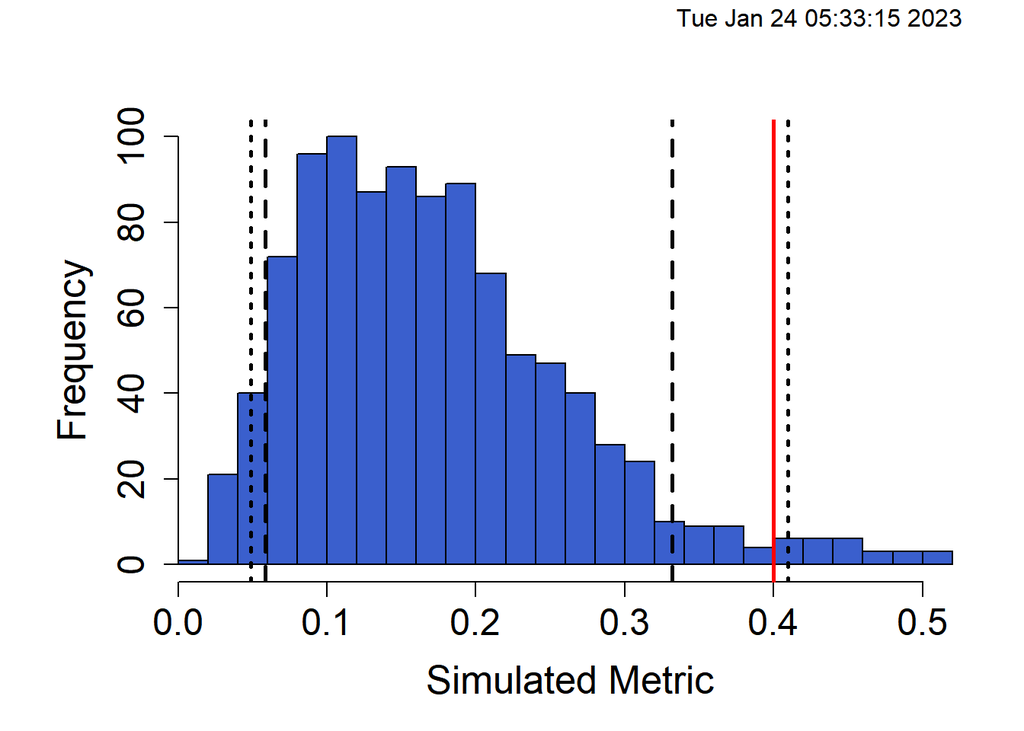

```r
plot(ecosim_BB_PAs)
```

### 3.6.3 BB vs PAw

```r
summary(ecosim_BB_PAw)
```

```
## Time Stamp:  Tue Jan 24 05:33:12 2023
## Reproducible:  FALSE
## Number of Replications:  1000
## Elapsed Time:  0.16 secs
## Metric:  pianka
## Algorithm:  ra3
## Observed Index:  0.45864
## Mean Of Simulated Index:  0.2022
## Variance Of Simulated Index:  0.0070847
## Lower 95% (1-tail):  0.088861
## Upper 95% (1-tail):  0.36341
## Lower 95% (2-tail):  0.070069
## Upper 95% (2-tail):  0.40131
## Lower-tail P =  0.993
## Upper-tail P =  0.008
## Observed metric > 992 simulated metrics
## Observed metric < 7 simulated metrics
## Observed metric = 1 simulated metrics
## Standardized Effect Size (SES):  3.0466
```

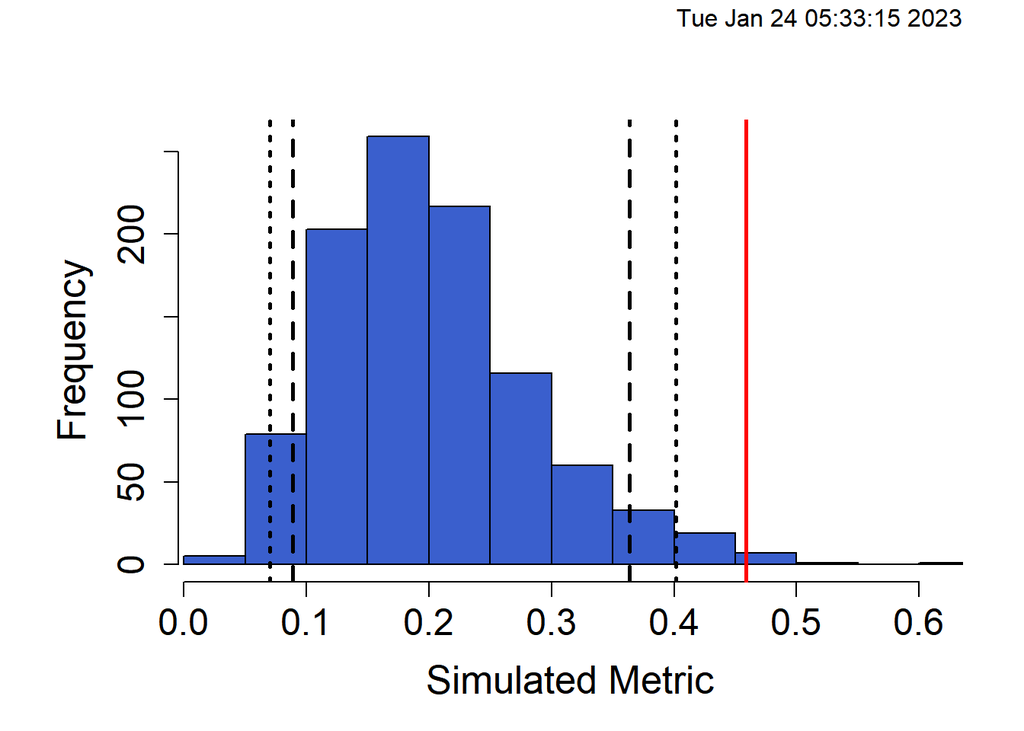

```r
plot(ecosim_BB_PAw)
```

### 3.6.4 BB vs PB

```r
summary(ecosim_BB_PB)
```

```
## Time Stamp:  Tue Jan 24 05:33:12 2023
## Reproducible:  FALSE
## Number of Replications:  1000
## Elapsed Time:  0.15 secs
## Metric:  pianka
## Algorithm:  ra3
## Observed Index:  0.34806
## Mean Of Simulated Index:  0.21325
## Variance Of Simulated Index:  0.0066392
## Lower 95% (1-tail):  0.089247
## Upper 95% (1-tail):  0.35743
## Lower 95% (2-tail):  0.071397
## Upper 95% (2-tail):  0.41053
## Lower-tail P =  0.943
## Upper-tail P =  0.058
## Observed metric > 942 simulated metrics
## Observed metric < 57 simulated metrics
## Observed metric = 1 simulated metrics
## Standardized Effect Size (SES):  1.6545
```

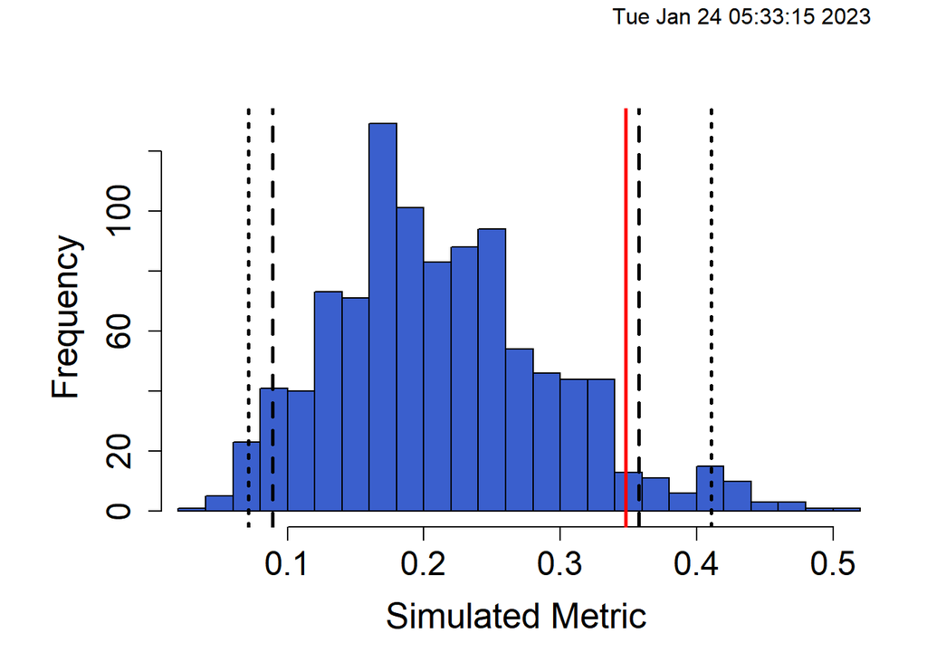

```r
plot(ecosim_BB_PB)
```

### 3.6.5 BB vs SLs

```r
summary(ecosim_BB_SLs)
```

```
## Time Stamp:  Tue Jan 24 05:33:12 2023
## Reproducible:  FALSE
## Number of Replications:  1000
## Elapsed Time:  0.16 secs
## Metric:  pianka
## Algorithm:  ra3
## Observed Index:  0.46918
## Mean Of Simulated Index:  0.16287
## Variance Of Simulated Index:  0.0082882
## Lower 95% (1-tail):  0.053403
## Upper 95% (1-tail):  0.34712
## Lower 95% (2-tail):  0.038145
## Upper 95% (2-tail):  0.41578
## Lower-tail P =  0.991
## Upper-tail P =  0.01
## Observed metric > 990 simulated metrics
## Observed metric < 9 simulated metrics
## Observed metric = 1 simulated metrics
## Standardized Effect Size (SES):  3.3646
```

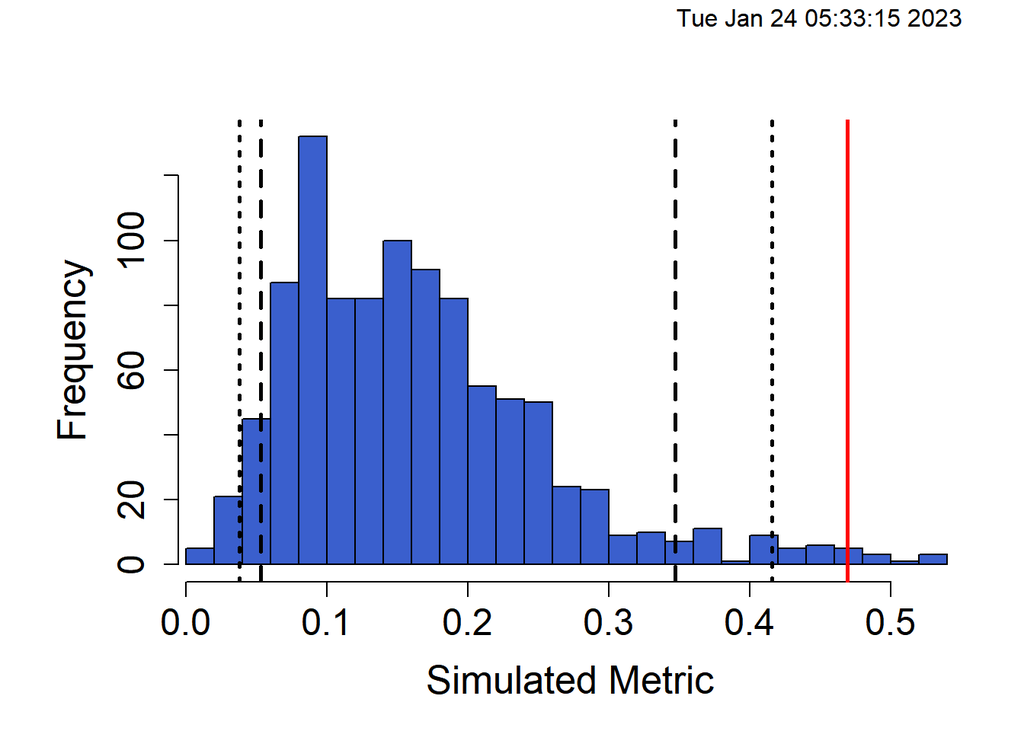

```r
plot(ecosim_BB_SLs)
```